# Stock Synthesis Recruitment Estimates

Markus Min

2026-03-31

## Background

Recruitment estimates are extracted from [stock assessments conducted within the last five years](https://www.pcouncil.org/stock-assessments-star-reports-stat-reports-rebuilding-analyses-terms-of-reference/groundfish-stock-assessment-documents/). Recruitment estimates were only extracted from assessments where recruitment deviations were estimated in the model. These assessments were all conducted using Stock Synthesis, which estimates annual recruitment in an integrated modeling framework, where recruitment is informed by multiple data sources to the model, but primarily age and length compositions.

The recruitment estimates we are using for this analysis are the log recruitment deviations around a Beverton-Holt stock-recruitment function, with their variability constrained by a parameter called SigmaR, which functions similarly to the standard deviation of a random effect. Recruitment deviations can either be estimated with a constraint where the annual deviations must sum to zero or where this constraint is lifted.

For our stocks, these stocks had a sum to zero constraint:

- Black Rockfish, Central CA (2023)
- Black Rockfish, Northern CA (2023)
- Black Rockfish, OR (2023)
- Black Rockfish, WA (2023)
- Canary Rockfish (2023)
- Dover Sole (2021)
- Lingcod, South of 40°10’N (2021)
- Lingcod, North of 40°10’N (2021)
- Quillback Rockfish, CA (2025)
- Rex Sole (2023)
- Vermilion/Sunset Rockfish, Southern CA (2021)
- Vermilion/Sunset Rockfish, Northern CA (2021)
- Vermilion/Sunset Rockfish, Oregon (2021)
- Vermilion/Sunset Rockfish, Washington (2021)
- Yelloweye Rockfish (2025)
- Yellowtail Rockfish (2025)

These stocks did not have a sum to zero constraint:

- Copper Rockfish, Southern CA (2023)
- Copper Rockfish, Northern CA (2023)
- Petrale Sole (2023)
- Rougheye/Blackspotted Rockfish (2025)
- Sablefish (2025)

#### Boom/bust

Recruitment is classified into boom, bust, and average categories for the purposes of visualization. These categories were produced by classifying any year with recruitment > 1 SD above the long-term mean a “boom” recruitment event, any year with recruitment < 1 SD below the long-term mean a “bust” recruitment event, and all years within 1 SD of the long-term mean an “average” year.

#### Autocorrelation

Autocorrelation in each of the recruitment time series is also visualized below. While persistent oceanographic conditions can lead to autocorrelation in recruitment deviations, autocorrelation may also result from aging error, which will “smear” out recruitment deviations and cause consecutive years to have autocorrelated recruitment deviations when in reality it is likely the signal from only one of these years being “smeared” across multiple years. This is particularly apparent in long-lived species, such as Yelloweye Rockfish (see below).

## Categorical recruitment + autocorrelation visualization

### Black Rockfish - Northern CA (2023 assessment)

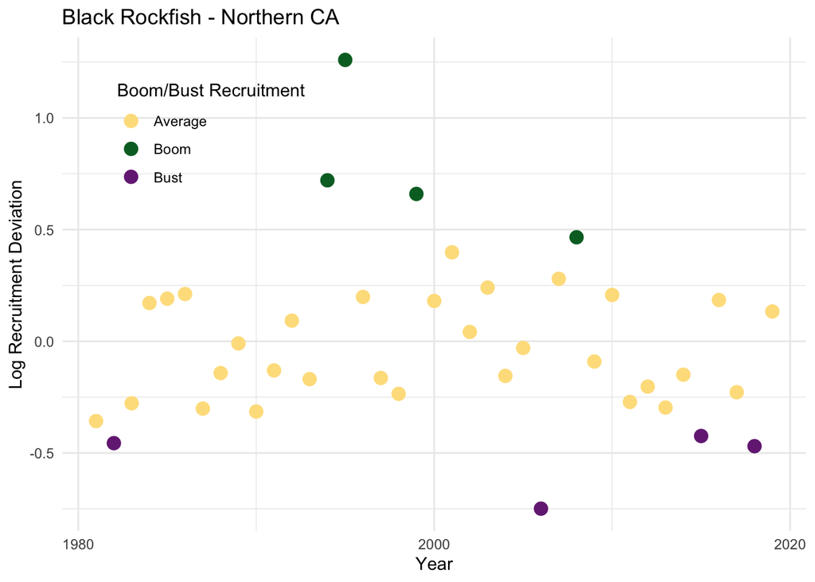

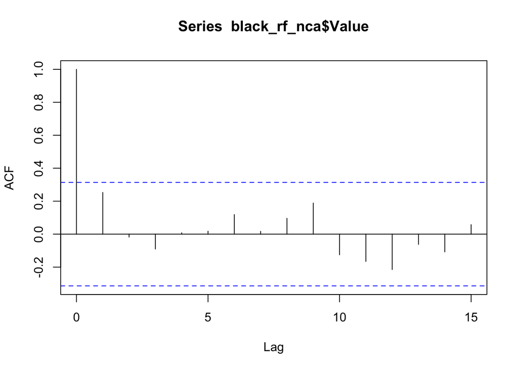

### Black Rockfish - Central CA (2023 assessment)

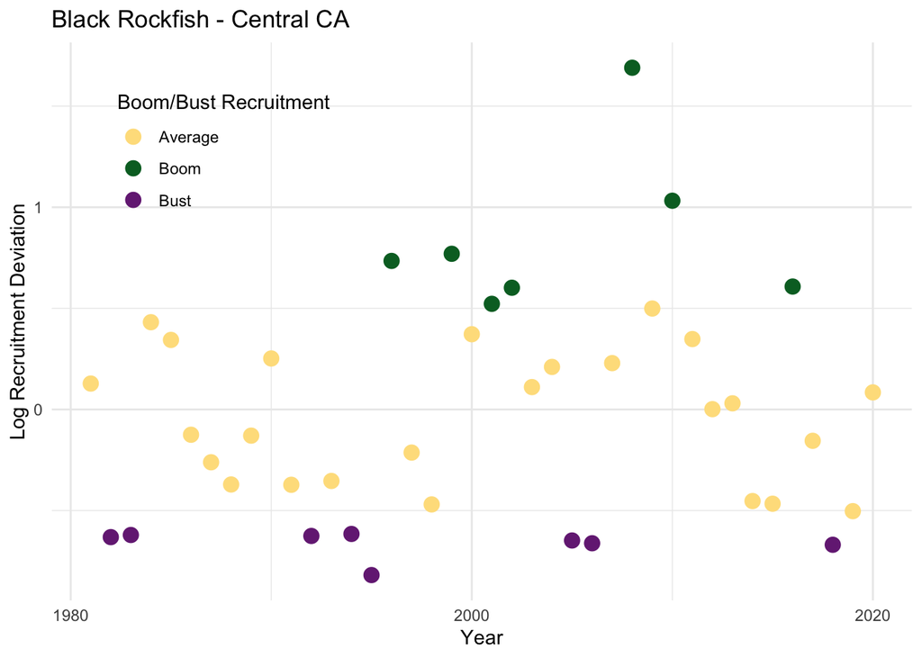

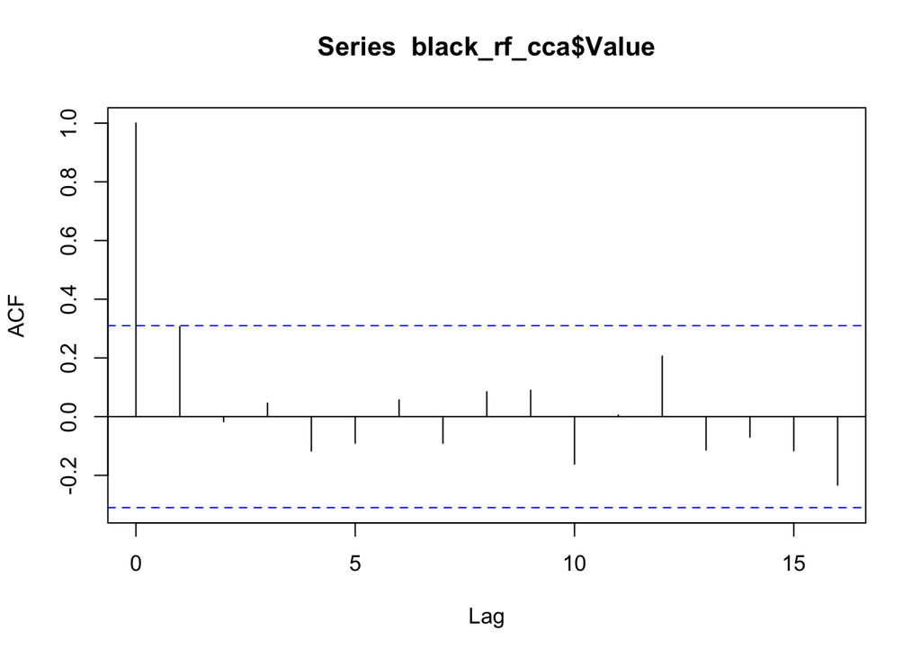

### Black Rockfish - Oregon (2023 assessment)

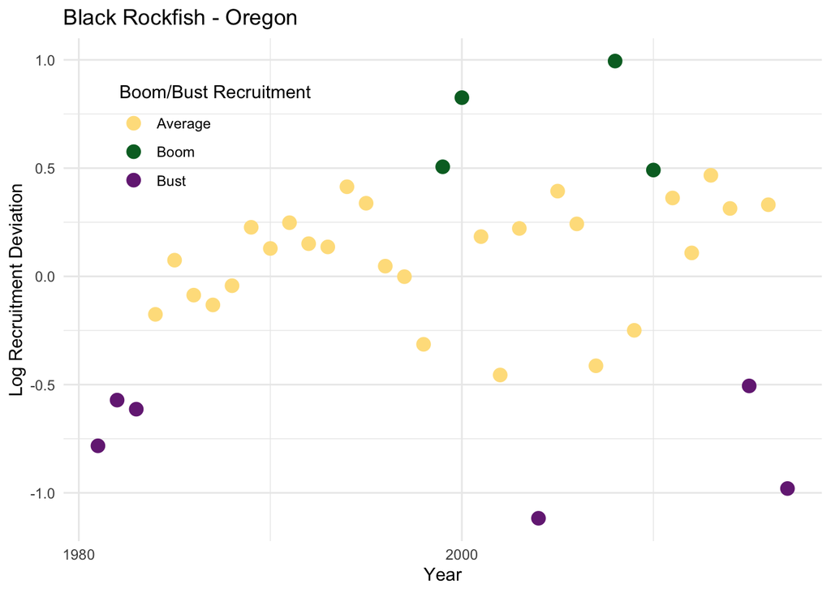

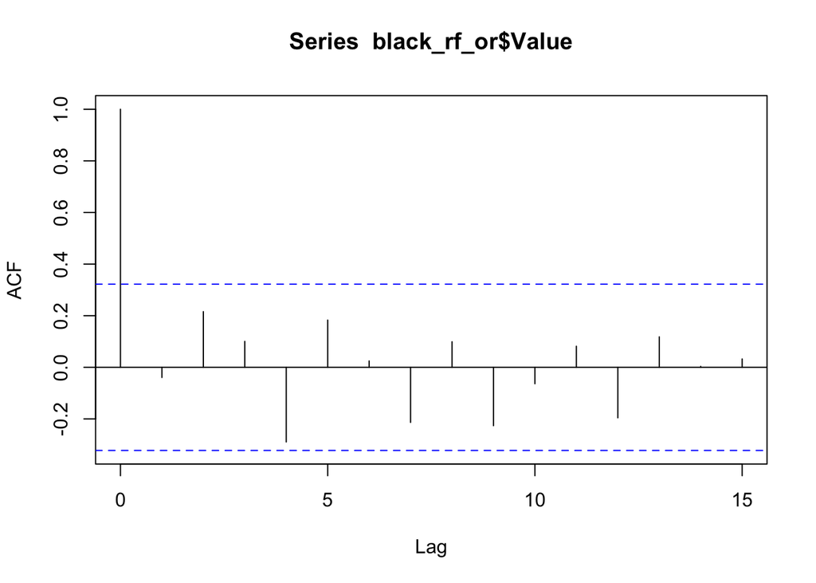

### Black Rockfish - Washington (2023 assessment)

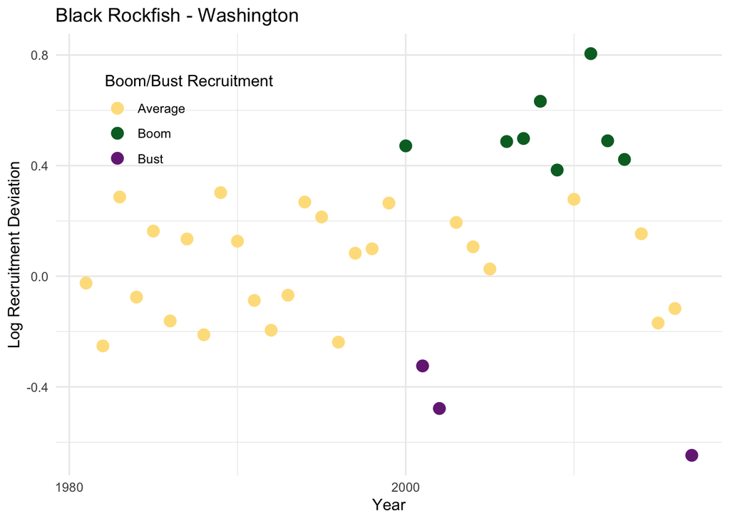

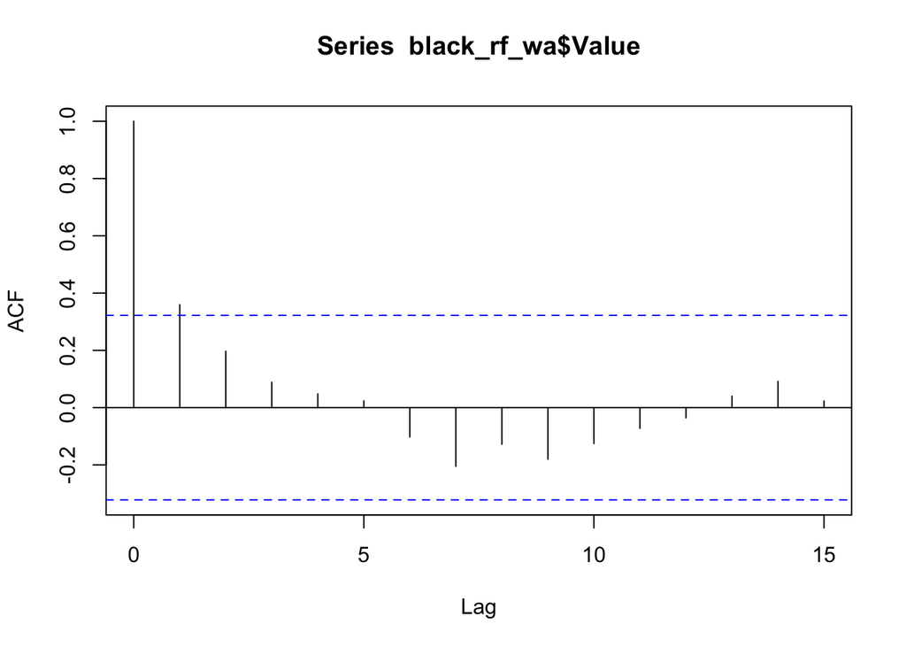

### Canary Rockfish (2023 assessment)

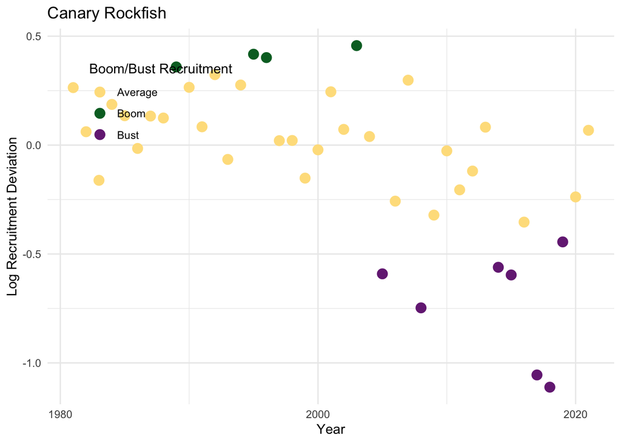

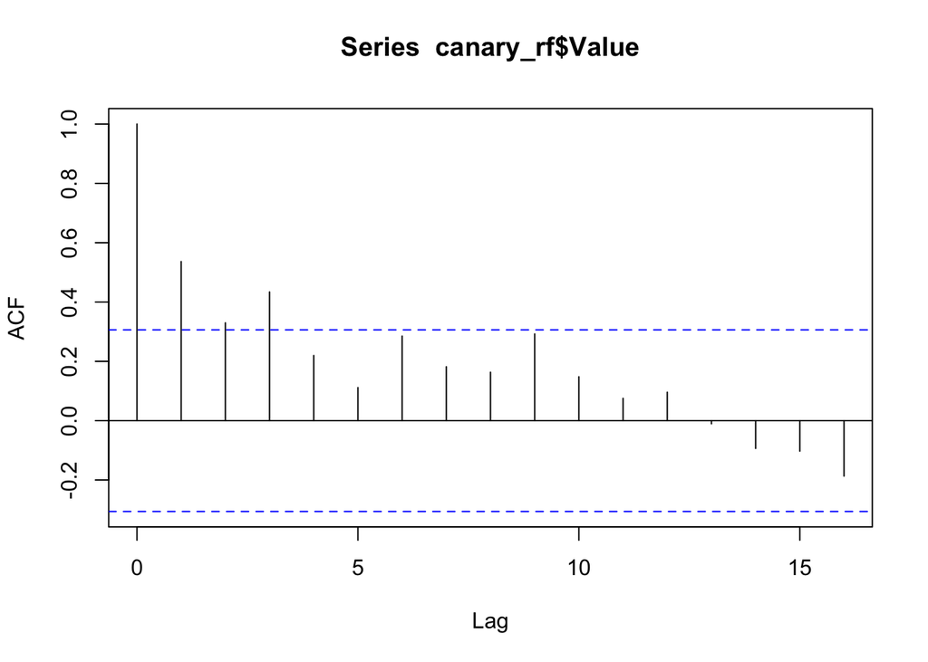

### Copper Rockfish - CA, North of Point Conception (2023 assessment)

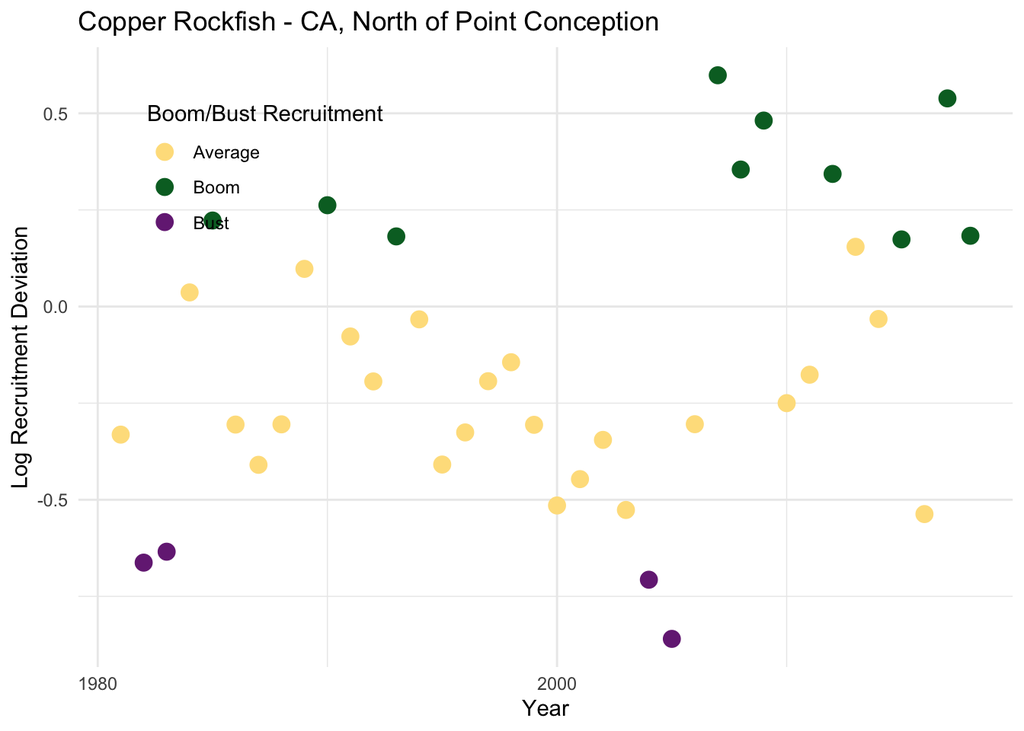

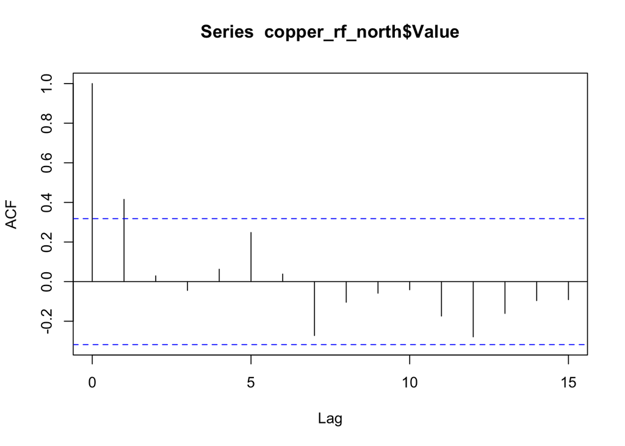

### Copper Rockfish - CA, South of Point Conception (2023 assessment)

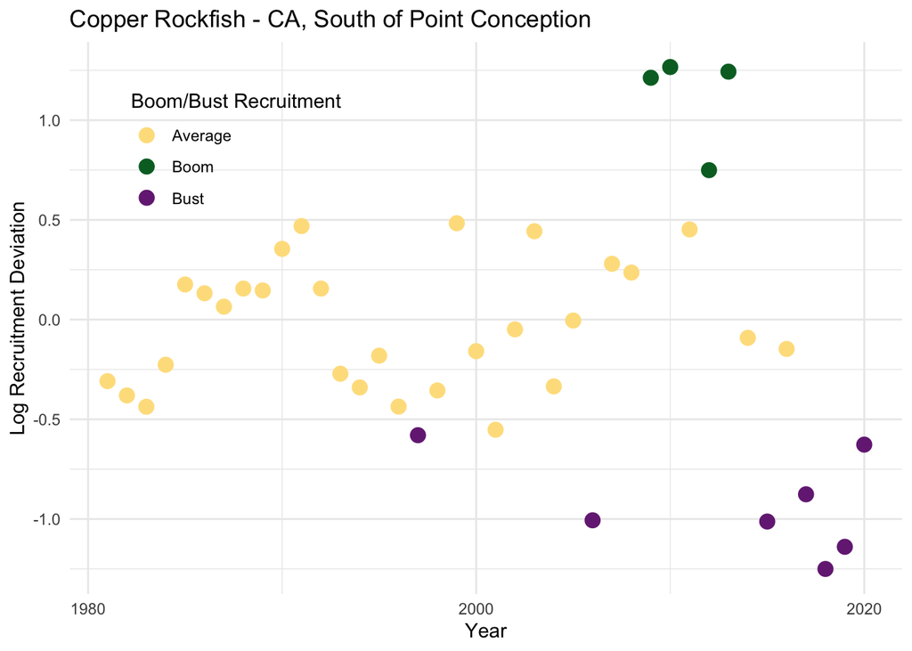

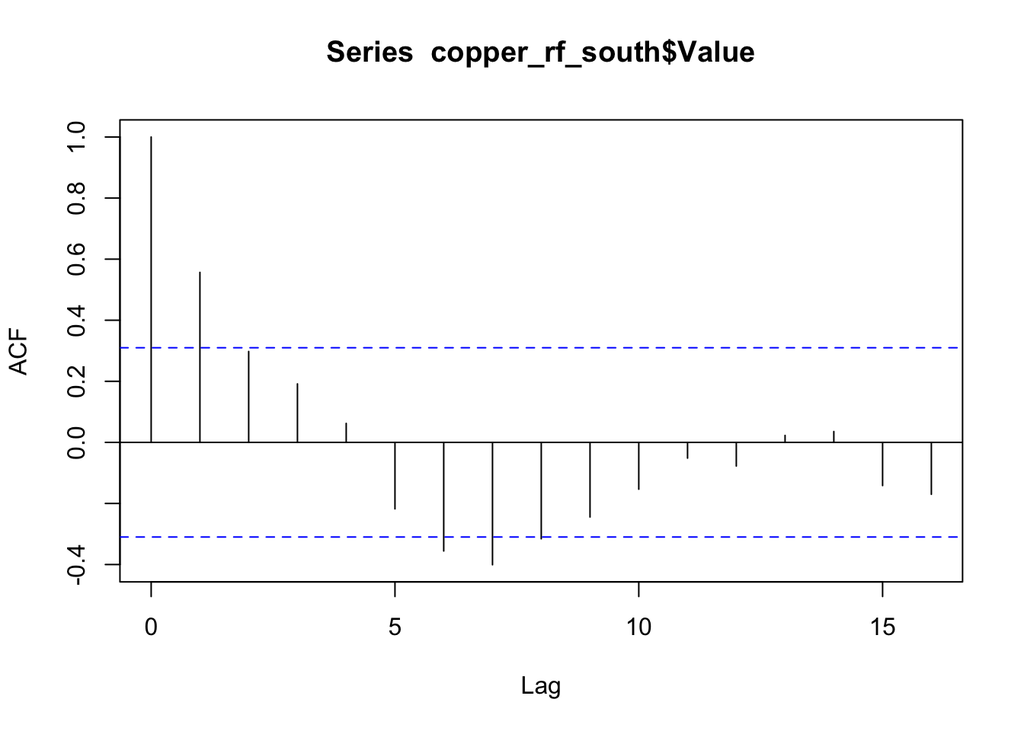

### Dover Sole (2021 assessment)

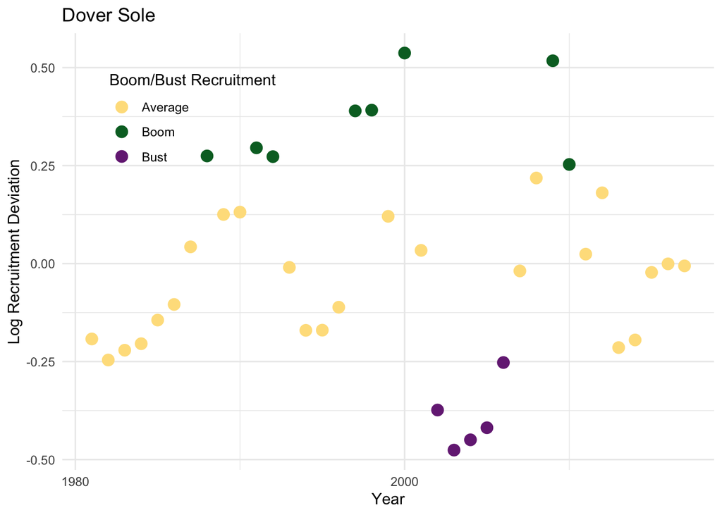

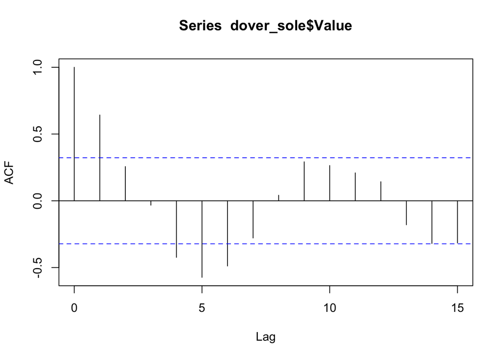

### Lingcod - North of 40°10’N (2021 assessment)

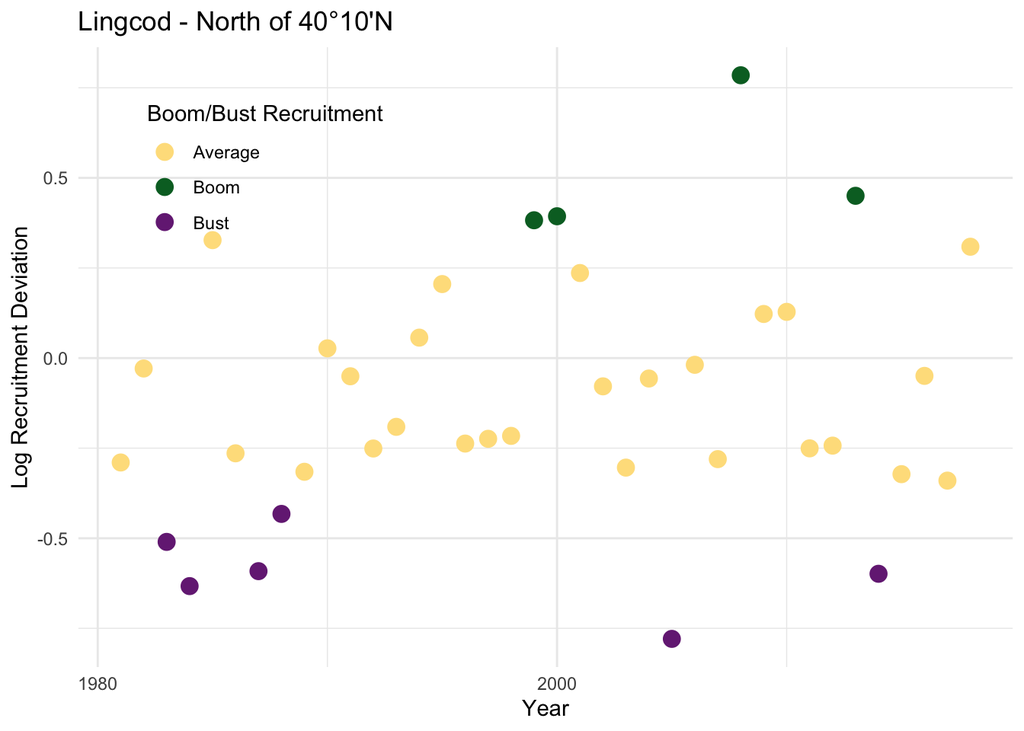

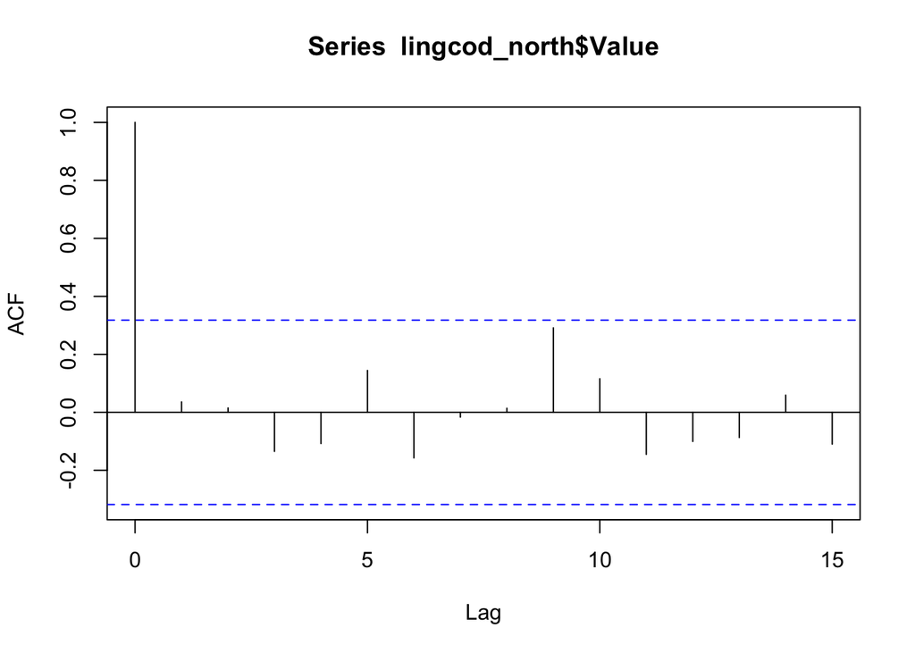

### Lingcod - South of 40°10’N (2021 assessment)

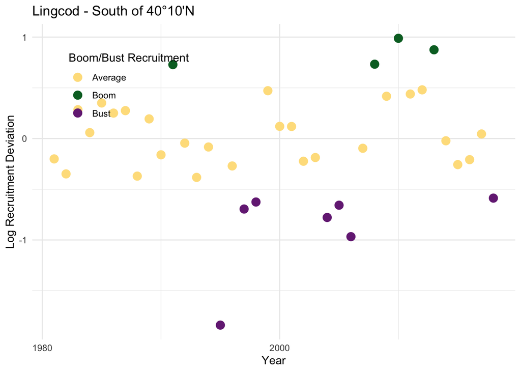

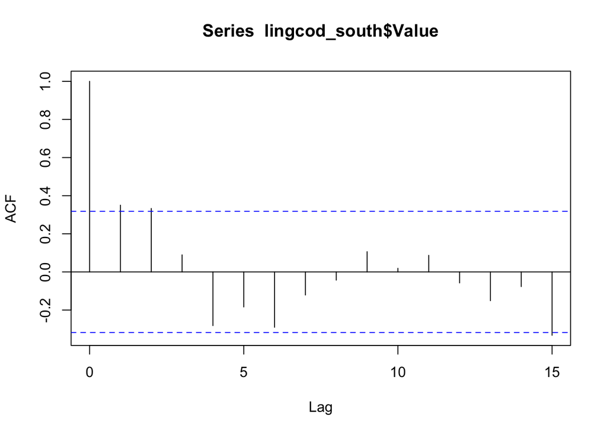

### Petrale Sole (2023 assessment)

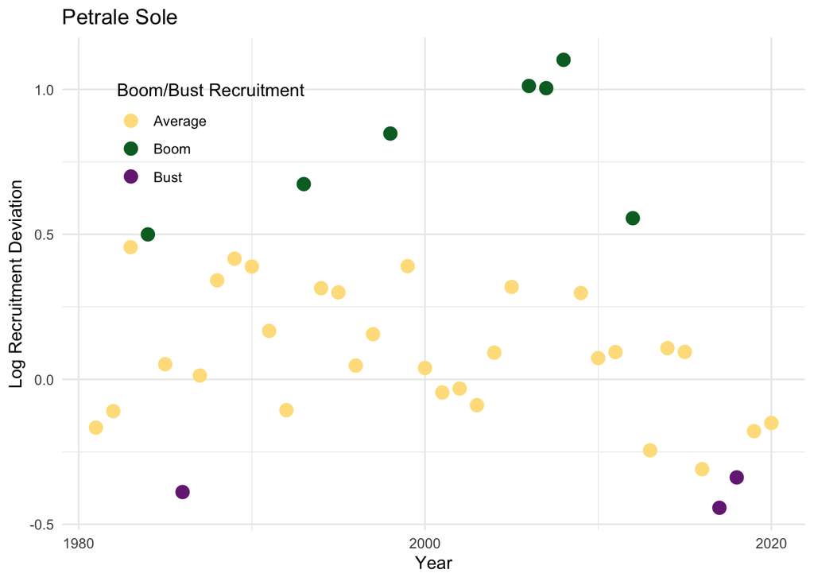

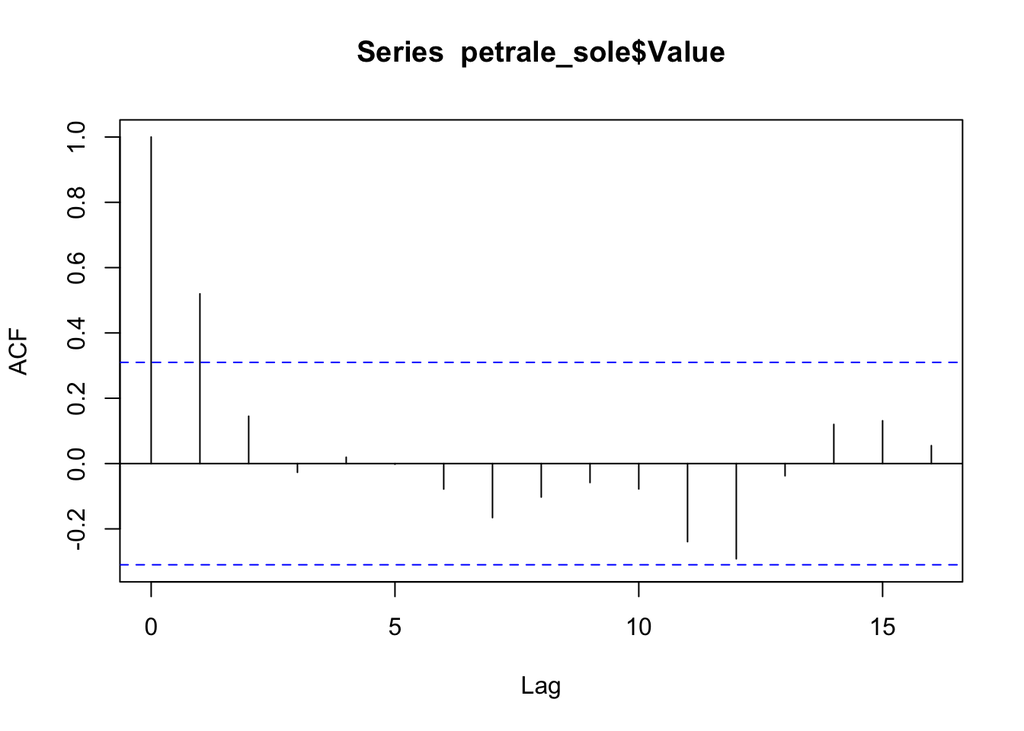

### Quillback Rockfish - California (2025 assessment)

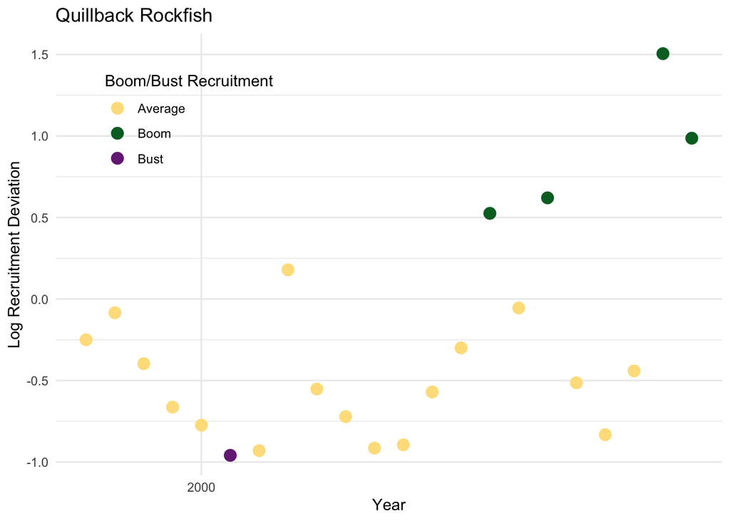

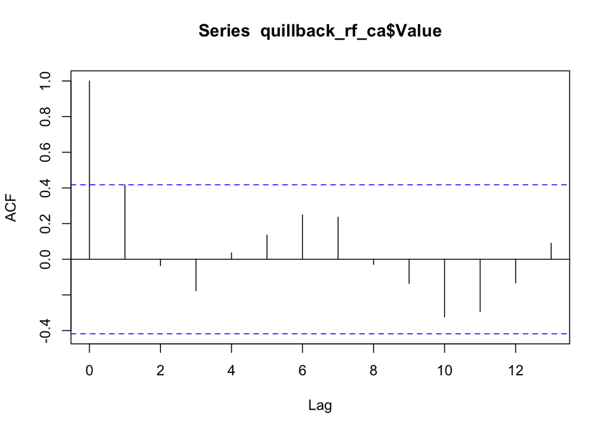

### Rex Sole (2023 assessment)

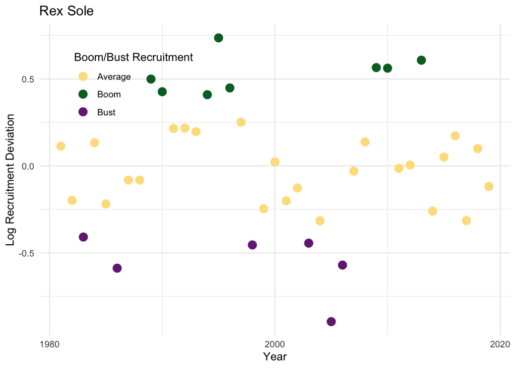

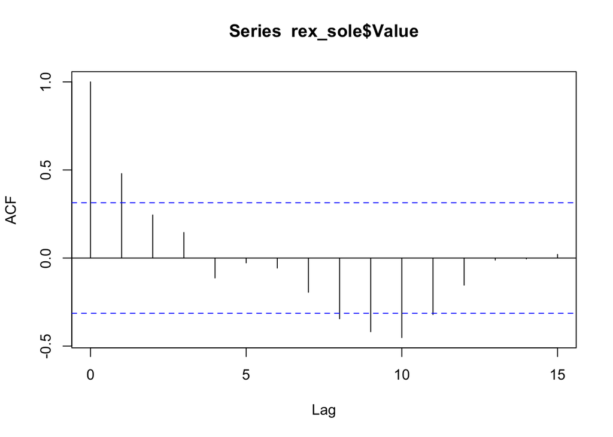

### Rougheye/Blackspotted Rockfish (2025 assessment)

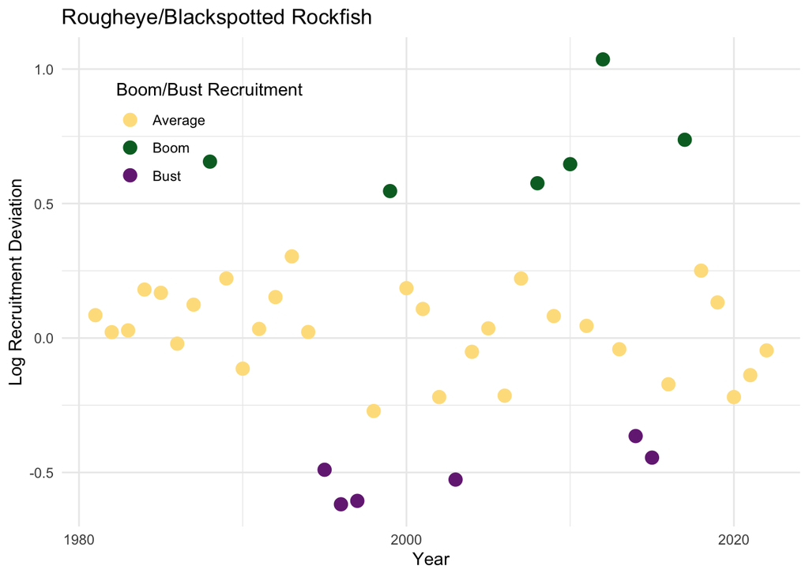

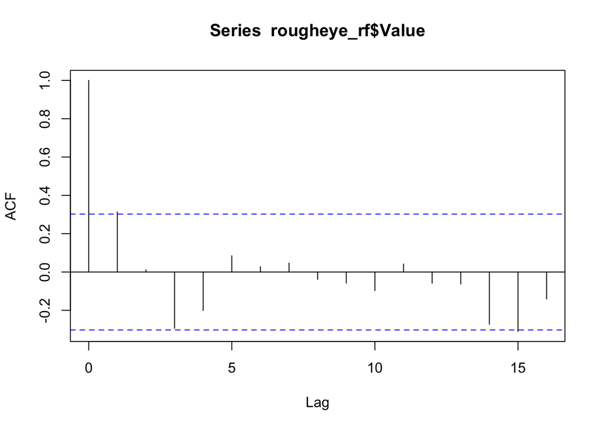

### Sablefish (2025 assessment)

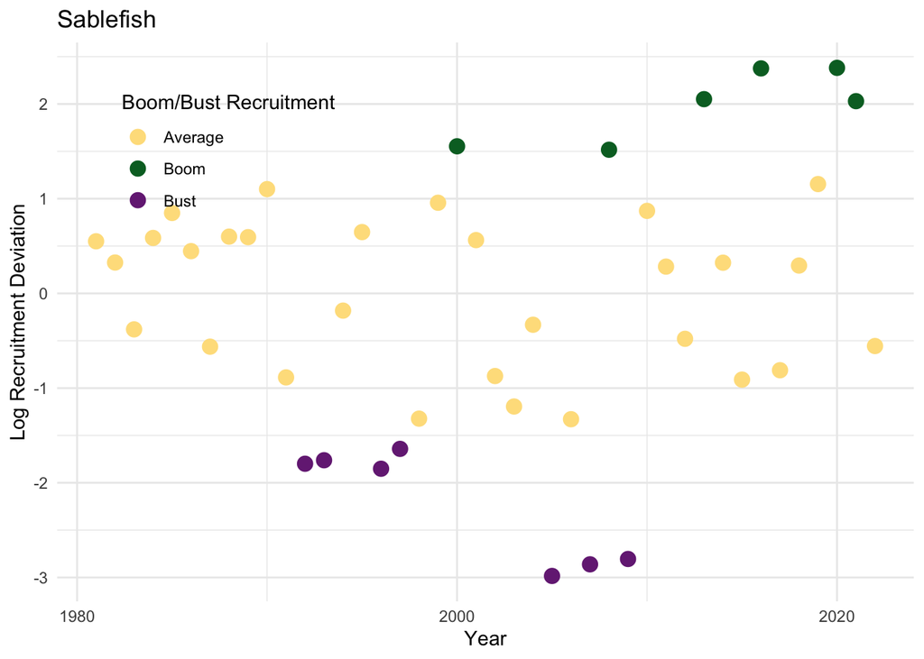

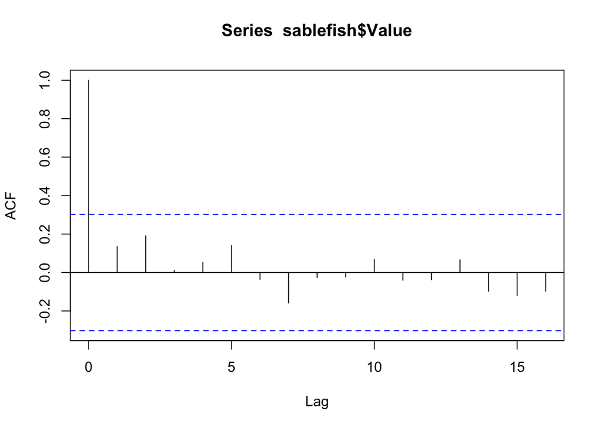

### Vermilion & Sunset Rockfish - Southern CA (2021 assessment)

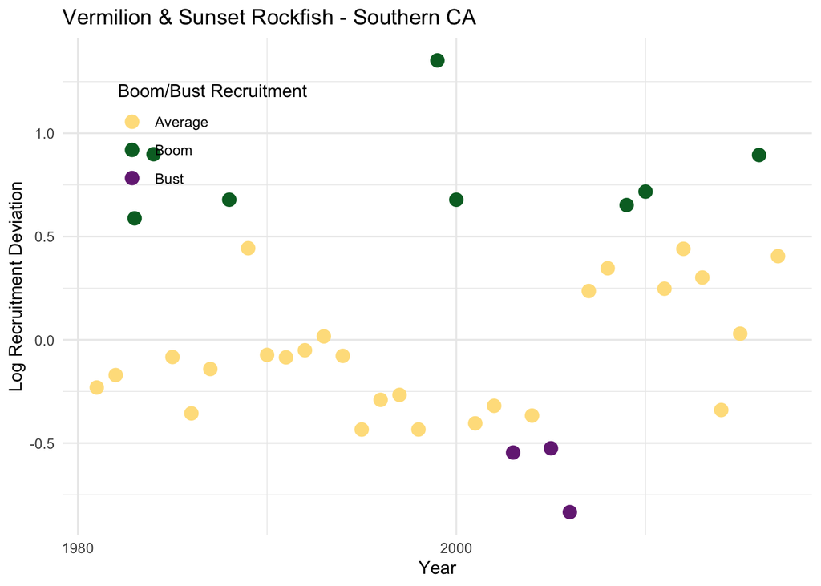

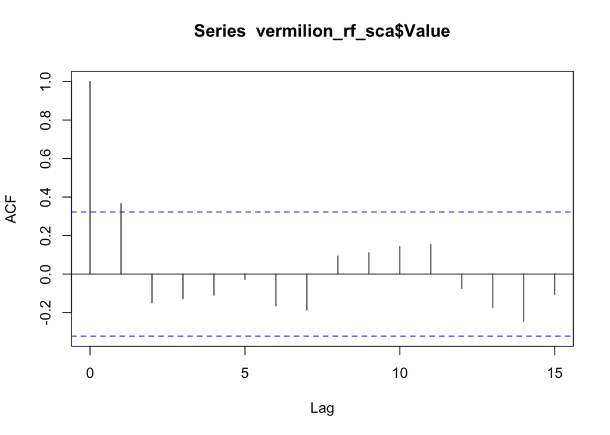